# aesqueda_core2

## Alfonso Esqueda

### EDA on Olympics Dataset

```python
#Import pandas, numpy, and matplotlib.

import numpy as np
import matplotlib.pyplot as plt
import pandas as pd
import seaborn as sns
```

```python
# Reading Olympics csv file
df = pd.read_csv('olympics.csv')
df
```

|  | Unnamed: 0 | ID | Name | Sex | Age | Height | Weight | Team | NOC | Games | Year | Season | City | Sport | Event | Medal | Country |
| --- | --- | --- | --- | --- | --- | --- | --- | --- | --- | --- | --- | --- | --- | --- | --- | --- | --- |
| 0 | 0 | 1 | A Dijiang | M | 24 | 180.0 | 176.36960 | China | CHN | 1992 Summer | 1992 | Summer | Barcelona | Basketball | Basketball Men's Basketball | NaN | China |
| 1 | 1 | 2 | A Lamusi | M | 23 | 170.0 | 132.27720 | China | CHN | 2012 Summer | 2012 | Summer | London | Judo | Judo Men's Extra-Lightweight | NaN | China |
| 2 | 2 | 602 | Abudoureheman | M | 22 | 182.0 | 165.34650 | China | CHN | 2000 Summer | 2000 | Summer | Sydney | Boxing | Boxing Men's Middleweight | NaN | China |
| 3 | 3 | 1463 | Ai Linuer | M | 25 | 160.0 | 136.68644 | China | CHN | 2004 Summer | 2004 | Summer | Athina | Wrestling | Wrestling Men's Lightweight, Greco-Roman | NaN | China |
| 4 | 4 | 1464 | Ai Yanhan | F | 14 | 168.0 | 119.04948 | China | CHN | 2016 Summer | 2016 | Summer | Rio de Janeiro | Swimming | Swimming Women's 200 metres Freestyle | NaN | China |
| ... | ... | ... | ... | ... | ... | ... | ... | ... | ... | ... | ... | ... | ... | ... | ... | ... | ... |
| 270762 | 270762 | 120575 | Mamorallo Tjoka | F | 23 | 150.0 | 123.45872 | Lesotho | LES | 2008 Summer | 2008 | Summer | Beijing | Athletics | Athletics Women's Marathon | NaN | Lesotho |
| 270763 | 270763 | 120575 | Mamorallo Tjoka | F | 27 | 150.0 | 123.45872 | Lesotho | LES | 2012 Summer | 2012 | Summer | London | Athletics | Athletics Women's Marathon | NaN | Lesotho |
| 270764 | 270764 | 122166 | M'apotlaki Ts'elho | F | 15 | NaN | NaN | Lesotho | LES | 1996 Summer | 1996 | Summer | Atlanta | Athletics | Athletics Women's 4 x 100 metres Relay | NaN | Lesotho |
| 270765 | 270765 | 122215 | Lefa Tsapi | M | 23 | 170.0 | 138.89106 | Lesotho | LES | 1984 Summer | 1984 | Summer | Los Angeles | Boxing | Boxing Men's Welterweight | NaN | Lesotho |
| 270766 | 270766 | 122299 | Mosolesa Tsie | M | 20 | 175.0 | 165.34650 | Lesotho | LES | 2000 Summer | 2000 | Summer | Sydney | Boxing | Boxing Men's Welterweight | NaN | Lesotho |

270767 rows × 17 columns

### 1. Impute the missing weight values. Explain your process and how you chose your imputation method.

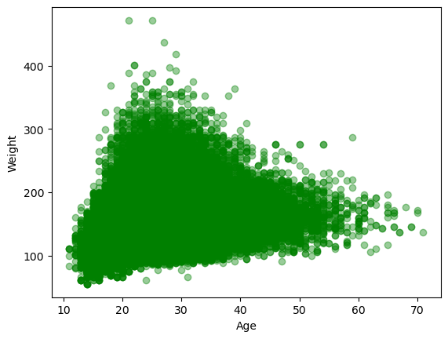

```python
plt.scatter( df['Age'], df['Weight'], alpha = 0.4, color = "green")
plt.xlabel("Age")
plt.ylabel("Weight")
plt.show()
```

```python
df["Weight"] = df["Weight"].fillna(df["Weight"].mean()).round(2)
print(df["Weight"])
```

```
0         176.37
1         132.28
2         165.35
3         136.69
4         119.05
           ...
270762    123.46
270763    123.46
270764    155.89
270765    138.89
270766    165.35
Name: Weight, Length: 270767, dtype: float64
```

#### I chose the mean (155.89) to fill in for the missing values in the weight column because it is equally distributed and there is not significant outliers in this dataframe.

#### To impute I used the .fillna() function and used the aggregate function .mean()

### 2. Impute the missing height values. Explain your process and how you chose your imputation method.

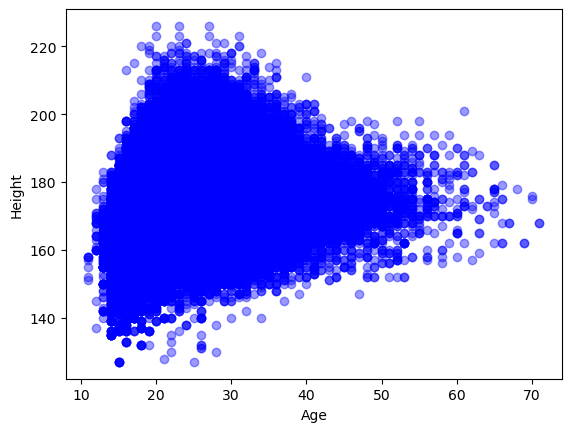

```python
plt.scatter( df['Age'], df['Height'], alpha = 0.4, color = "blue")
plt.xlabel("Age")
plt.ylabel("Height")
plt.show()
```

```python
df["Height"] = df["Height"].fillna(df["Height"].mean()).round(2)
print(df["Height"])
```

```
0         180.00
1         170.00
2         182.00
3         160.00
4         168.00
           ...
270762    150.00
270763    150.00
270764    175.34
270765    170.00
270766    175.00
Name: Height, Length: 270767, dtype: float64
```

#### I chose the mean (175.34) to fill in for the missing values in the height column because it is equally distributed and there is not significant outliers in this dataframe.

#### To impute I used the .fillna() function and used the aggregate function .mean()

### 3. Impute the ‘missing’ medal values. Hint: Replace the NaN values with something that represents a non medal winner.

```python
df["Medal"] = df["Medal"].fillna("MISSING")
df
```

|  | Unnamed: 0 | ID | Name | Sex | Age | Height | Weight | Team | NOC | Games | Year | Season | City | Sport | Event | Medal | Country |
| --- | --- | --- | --- | --- | --- | --- | --- | --- | --- | --- | --- | --- | --- | --- | --- | --- | --- |
| 0 | 0 | 1 | A Dijiang | M | 24 | 180.00 | 176.37 | China | CHN | 1992 Summer | 1992 | Summer | Barcelona | Basketball | Basketball Men's Basketball | MISSING | China |
| 1 | 1 | 2 | A Lamusi | M | 23 | 170.00 | 132.28 | China | CHN | 2012 Summer | 2012 | Summer | London | Judo | Judo Men's Extra-Lightweight | MISSING | China |
| 2 | 2 | 602 | Abudoureheman | M | 22 | 182.00 | 165.35 | China | CHN | 2000 Summer | 2000 | Summer | Sydney | Boxing | Boxing Men's Middleweight | MISSING | China |
| 3 | 3 | 1463 | Ai Linuer | M | 25 | 160.00 | 136.69 | China | CHN | 2004 Summer | 2004 | Summer | Athina | Wrestling | Wrestling Men's Lightweight, Greco-Roman | MISSING | China |
| 4 | 4 | 1464 | Ai Yanhan | F | 14 | 168.00 | 119.05 | China | CHN | 2016 Summer | 2016 | Summer | Rio de Janeiro | Swimming | Swimming Women's 200 metres Freestyle | MISSING | China |
| ... | ... | ... | ... | ... | ... | ... | ... | ... | ... | ... | ... | ... | ... | ... | ... | ... | ... |
| 270762 | 270762 | 120575 | Mamorallo Tjoka | F | 23 | 150.00 | 123.46 | Lesotho | LES | 2008 Summer | 2008 | Summer | Beijing | Athletics | Athletics Women's Marathon | MISSING | Lesotho |
| 270763 | 270763 | 120575 | Mamorallo Tjoka | F | 27 | 150.00 | 123.46 | Lesotho | LES | 2012 Summer | 2012 | Summer | London | Athletics | Athletics Women's Marathon | MISSING | Lesotho |
| 270764 | 270764 | 122166 | M'apotlaki Ts'elho | F | 15 | 175.34 | 155.89 | Lesotho | LES | 1996 Summer | 1996 | Summer | Atlanta | Athletics | Athletics Women's 4 x 100 metres Relay | MISSING | Lesotho |
| 270765 | 270765 | 122215 | Lefa Tsapi | M | 23 | 170.00 | 138.89 | Lesotho | LES | 1984 Summer | 1984 | Summer | Los Angeles | Boxing | Boxing Men's Welterweight | MISSING | Lesotho |
| 270766 | 270766 | 122299 | Mosolesa Tsie | M | 20 | 175.00 | 165.35 | Lesotho | LES | 2000 Summer | 2000 | Summer | Sydney | Boxing | Boxing Men's Welterweight | MISSING | Lesotho |

270767 rows × 17 columns

### 4. Convert height from centimeters to inches or feet/inches. Replace the current height values with these converted values.

```python
# Multiply the column by the conversion factor
df['Height'] = df['Height'] / 2.54
df['Height'] = df['Height'] / 12
# Round the resulting values to 2 decimal places
df['Height'] = df['Height'].round(2)
```

```python
df['Height'].head()
```

```
0    5.91
1    5.58
2    5.97
3    5.25
4    5.51
Name: Height, dtype: float64
```

## Using any form of EDA (unless otherwise noted), answer the following questions:

### 5. How many medals has the United States won?

```python
usa = df[df['Country'] == 'USA']
usa.loc[0:, ["Medal"]].value_counts()
```

```
Medal
MISSING    13216
Gold        2638
Silver      1641
Bronze      1358
dtype: int64
```

#### The total medals for the US is 5,637 medals

### 6. Select an event of your choice: What is the average age, weight, and height of Medalists vs non-Medalists?

```python
#Both medalists and nonmedalists are in this dataframe
track = df[df['Event'] == "Athletics Men's 800 metres"]
track_no_medal = track[track["Medal"] == "MISSING"]
track_medal = track[track["Medal"] != "MISSING"]

print("Non-medalists Athletes")
print(track_no_medal[["Age", "Weight", "Height"]].mean().round(2))

print("-------------------------------")
print("Medalists Athletes")
print(track_medal[["Age", "Weight", "Height"]].mean().round(2))
```

```
Non-medalists Athletes
Age        23.97
Weight    150.50
Height      5.84
dtype: float64
-------------------------------
Medalists Athletes
Age        24.24
Weight    152.34
Height      5.91
dtype: float64
```

### 7. Select a country of your choice: What Olympic event do they have the most gold Medals in?

```python
china = df[df['Country'] == 'China']
china_medal = china[china['Medal'] ==  'Gold']
china_medal.loc[0:, ["Medal", "Event"]].value_counts().head()
```

```
Medal  Event
Gold   Volleyball Women's Volleyball           34
       Gymnastics Men's Team All-Around        17
       Badminton Women's Doubles               10
       Diving Women's Synchronized Platform    10
       Table Tennis Men's Doubles              10
dtype: int64
```

### China has 34 Gold medals in the Volleyball Women's Volleyball.

### 8. Using a bar chart, show the top 15 countries with the most Medals won.

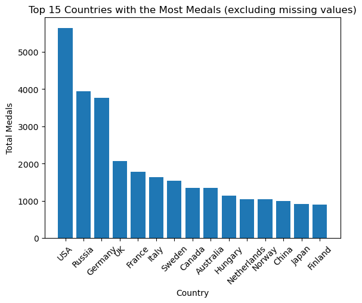

```python
# replace the string "MISSING" with NaN (missing value)
df['Medal'].replace('MISSING', np.nan, inplace=True)

# create a new DataFrame with the total medals won by each country (excluding missing values)
medal_counts = df.dropna(subset=['Medal']).groupby(['Country'])['Medal'].count().reset_index(name='Total Medals')

# sort the DataFrame by the total medals won in descending order and take the top 15 countries
top_15 = medal_counts.sort_values('Total Medals', ascending=False).head(15)

# create a bar chart of the top 15 countries by total medals won
plt.bar(top_15['Country'], top_15['Total Medals'])

# set the title and axis labels
plt.title('Top 15 Countries with the Most Medals (excluding missing values)')
plt.xlabel('Country')
plt.ylabel('Total Medals')

# rotate the x-axis labels for better readability
plt.xticks(rotation=45)

# display the bar chart
plt.show()
```

### 9. Is there a correlation between Weight and Height? Justify your answer. Hint: use a scatterplot

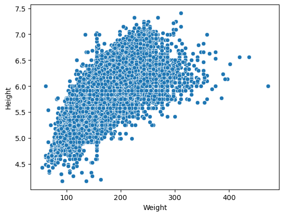

```python
sns.scatterplot(data=df, x="Weight", y="Height")
```

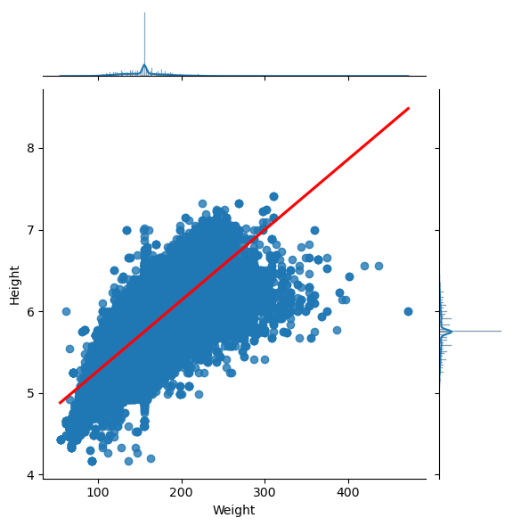

```python
g = sns.jointplot(x="Weight", y="Height", data=df, kind='reg')
regline = g.ax_joint.get_lines()[0]
regline.set_color('red')
regline.set_zorder(5)
```

### The weight and height variable are highly correlated due to the linear correlation in the graph depicted above.

### 10. What is the distribution of silver Medalists and Age? What is the skewness of the data? Justify your answer. Hint: use a histogram

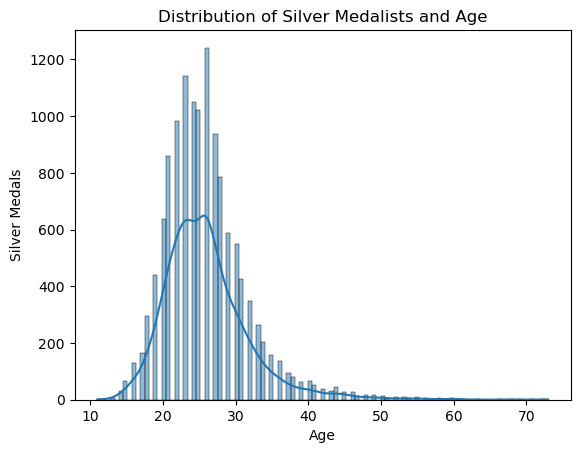

```python
silver_medals = df[df["Medal"] == "Silver"]
# Visualize the distribution of the target variable
sns.histplot(silver_medals["Age"], kde=True)
plt.title("Distribution of Silver Medalists and Age")
plt.xlabel("Age")
plt.ylabel("Silver Medals")
plt.show()
```

### The graph above is right skewed and positive due to the long tail to the right. A skewed distribution means that the data is not symmetrical and is skewed towards one end. In the case of a right-skewed distribution, most of the data is concentrated on the left side of the histogram, and the tail extends towards the right side.